# Linear models for penguins data

Michael Friendly

11 Feb 2021

## Load packages

```r
library(dplyr)
library(ggplot2)
library(car)
library(effects)
library(palmerpenguins)
```

## Clean up variable names, get rid of NAs, etc.

Remove units from variable names (for display purposes). Character variables should be factors.

```r
peng <- penguins %>%
    rename(
         bill_length = bill_length_mm,
         bill_depth = bill_depth_mm,
         flipper_length = flipper_length_mm,
         body_mass = body_mass_g
         ) %>%
  mutate(species = as.factor(species),
         island = as.factor(island),
         sex = as.factor(substr(sex,1,1))) %>%
  filter(!is.na(bill_depth),
         !is.na(sex))

str(peng)
```

```
## tibble [333 x 8] (S3: tbl_df/tbl/data.frame)
##  $ species       : Factor w/ 3 levels "Adelie","Chinstrap",..: 1 1 1 1 1 1 1 1 1 1 ...
##  $ island        : Factor w/ 3 levels "Biscoe","Dream",..: 3 3 3 3 3 3 3 3 3 3 ...
##  $ bill_length   : num [1:333] 39.1 39.5 40.3 36.7 39.3 38.9 39.2 41.1 38.6 34.6 ...
##  $ bill_depth    : num [1:333] 18.7 17.4 18 19.3 20.6 17.8 19.6 17.6 21.2 21.1 ...
##  $ flipper_length: int [1:333] 181 186 195 193 190 181 195 182 191 198 ...
##  $ body_mass     : int [1:333] 3750 3800 3250 3450 3650 3625 4675 3200 3800 4400 ...
##  $ sex           : Factor w/ 2 levels "f","m": 2 1 1 1 2 1 2 1 2 2 ...
##  $ year          : int [1:333] 2007 2007 2007 2007 2007 2007 2007 2007 2007 2007 ...
```

## Function to reproduce ggplot2 default colors

```r
ggplotColours <- function(n = 6, h = c(0, 360) + 15){
  if ((diff(h) %% 360) < 1) h[2] <- h[2] - 360/n
  hcl(h = (seq(h[1], h[2], length = n)), c = 100, l = 65)
}
```

## Scatterplot matrix

`car::scatterplotMatrix` with data ellipses and regression lines by species

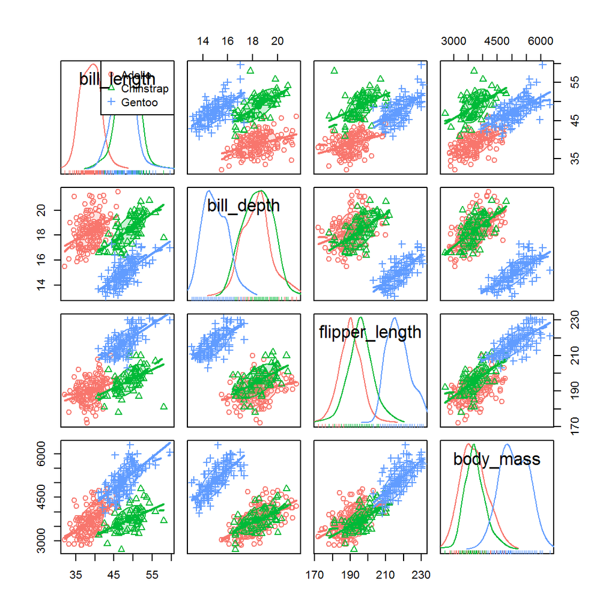

```r
scatterplotMatrix(~ bill_length + bill_depth + flipper_length + body_mass | species,
                  data=peng,
                  col = ggplotColours(3),
                  ellipse=list(levels=0.68))
```

## Faceted plot by island

Assume our main interest is in understanding how `bill_length` is related to other variables. We can easily include categorical predictors (`sex` and `island`) using color and faceting.

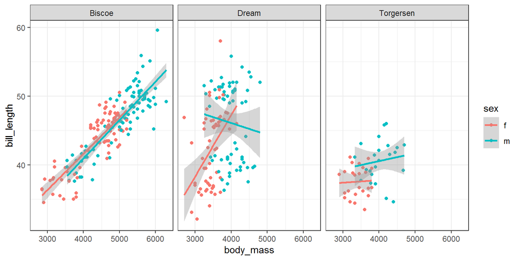

```r
ggplot(peng, aes(x=body_mass, y=bill_length, color=sex)) +
  geom_point() +
  geom_smooth(method="lm", formula = "y ~ x") +
  facet_grid(~ island) +
  theme_bw()
```

## Quick checks for non-linear relations

Fitting a quadratic with `geom_smooth()` is one simple way to check for non-linearity. Another is to use a `method="loess"` smoother.

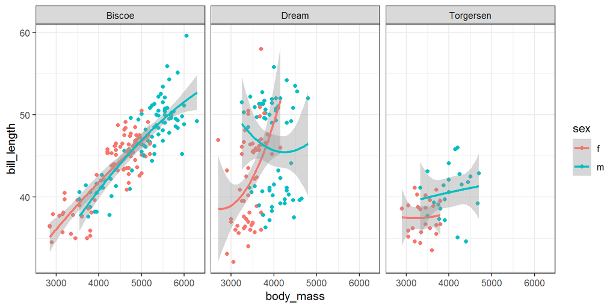

```r
ggplot(peng, aes(x=body_mass, y=bill_length, color=sex)) +
  geom_point() +
  geom_smooth(method="lm", formula = "y ~ poly(x,2)") +
  facet_grid(~ island) +
  theme_bw()
```

Do the same, but facet by island & species

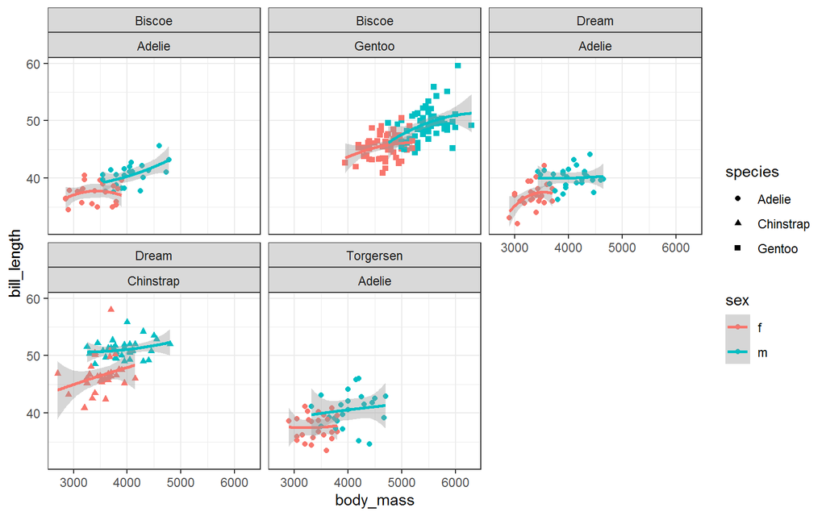

```r
ggplot(peng, aes(x=body_mass, y=bill_length, color=sex, shape=species)) +
  geom_point() +
  geom_smooth(method="lm", formula = "y ~ poly(x,2)") +
  facet_wrap(island ~ species) +
  theme_bw()
```

## Fit a model for `bill_length`

Here, use `body_mass` as main quantitative predictor, but control for `sex`, `species` and `island`

```r
peng.mod0 <- lm(bill_length ~ body_mass + sex + species + island, data=peng)
Anova(peng.mod0)
```

```
## Anova Table (Type II tests)
##
## Response: bill_length
##           Sum Sq  Df F value  Pr(>F)
## body_mass    100   1   19.61 1.3e-05 ***
## sex          251   1   49.12 1.4e-11 ***
## species     3572   2  349.25 < 2e-16 ***
## island         9   2    0.89    0.41
## Residuals   1667 326
## ---
## Signif. codes:  0 '***' 0.001 '**' 0.01 '*' 0.05 '.' 0.1 ' ' 1
```

### Try an interaction term

```r
peng.mod1 <- lm(bill_length ~ body_mass * sex + species + island, data=peng)
Anova(peng.mod1)
```

```
## Anova Table (Type II tests)
##
## Response: bill_length
##               Sum Sq  Df F value  Pr(>F)
## body_mass        100   1   19.55 1.3e-05 ***
## sex              251   1   48.97 1.5e-11 ***
## species         3527   2  343.76 < 2e-16 ***
## island             9   2    0.89    0.41
## body_mass:sex      0   1    0.00    0.96
## Residuals       1667 325
## ---
## Signif. codes:  0 '***' 0.001 '**' 0.01 '*' 0.05 '.' 0.1 ' ' 1
```

### Test all interactions

This is a simple screening test to check whether any interactions with `body_mass` are important.

```r
peng.mod2 <- lm(bill_length ~ body_mass * (sex + species + island), data=peng)
Anova(peng.mod2)
```

```
## Anova Table (Type II tests)
##
## Response: bill_length
##                   Sum Sq  Df F value  Pr(>F)
## body_mass            100   1   19.69 1.3e-05 ***
## sex                  256   1   50.25 8.6e-12 ***
## species             3383   2  331.98 < 2e-16 ***
## island                 9   2    0.91    0.40
## body_mass:sex          5   1    1.04    0.31
## body_mass:species     22   2    2.12    0.12
## body_mass:island       2   2    0.17    0.84
## Residuals           1636 321
## ---
## Signif. codes:  0 '***' 0.001 '**' 0.01 '*' 0.05 '.' 0.1 ' ' 1
```

### Compare models

```r
anova(peng.mod0, peng.mod1, peng.mod2)
```

```
## Analysis of Variance Table
##
## Model 1: bill_length ~ body_mass + sex + species + island
## Model 2: bill_length ~ body_mass * sex + species + island
## Model 3: bill_length ~ body_mass * (sex + species + island)
##   Res.Df  RSS Df Sum of Sq    F Pr(>F)
## 1    326 1667
## 2    325 1667  1      0.01 0.00   0.96
## 3    321 1636  4     31.44 1.54   0.19
```

## Effect plots

By default, this plots the mean response (`bill_length`) all the high-order terms in the model (`species`, `island`, and `body_mass * sex`), averaged over all other variables not shown in a given plot.

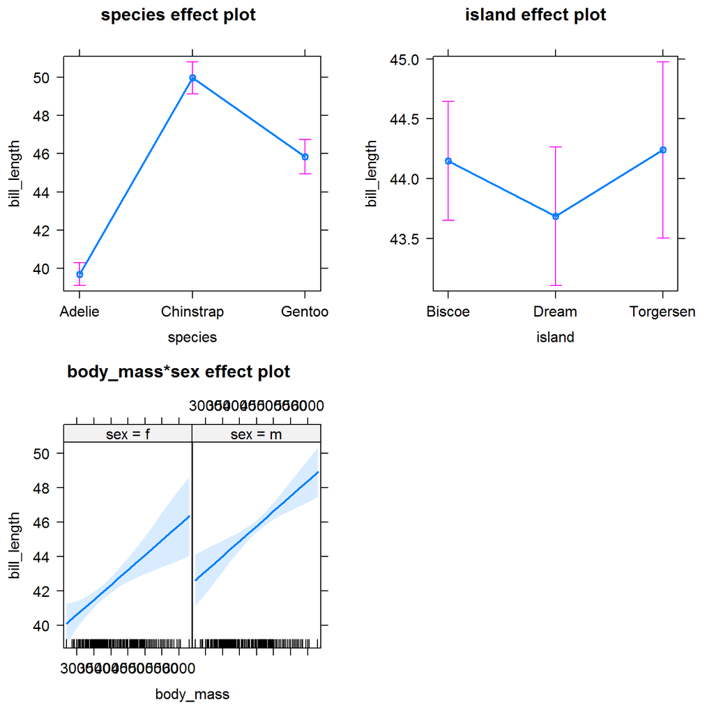

```r
peng.eff <- allEffects(peng.mod1)
plot(peng.eff)
```